# Dashboard Template

February 02, 2026

```r
library(tidyverse)
library(here)
model_data <- here("data","model","model_data_2.3.rds") %>% read_rds()
pred_2026 <- here("data","model","pred_2026.rds") %>%  read_rds() %>% filter( year == "2026")

week_metrics_by_category <- here("data","processed","week_metrics_by_category.rds") %>% read_rds()
week_metrics <- here("data","processed","week_metrics.rds") %>% read_rds()
bakery_data <- here("data","processed","bakery_totals_by_date.rds") %>% read_rds()
```

# 1 Overview

Historical and predicted number of items sold for a given time period [month_selection] default June

- This provides reasonable (and I think, so far best) proxy for overall traffic
- May be used for projecting
  - staffing
  - weekly orders

Below predicted items sold per day, week, and month.

```r
week_labels = pred_2026 %>%  group_by(season_week) %>%
  summarize(
    start_date = min(date),
    .groups = "drop"
  ) %>% mutate(
    date_md = str_sub(start_date, 6),
    week_label = paste("week", season_week, "-", date_md)
  )
#glimpse(week_labels)
```

## 1.1 Predicted and Actual Number of Items Sold by day

```r
years = paste(2024:2026)
#pred_2026 %>% glimpse()
data_2026_pred <- pred_2026 %>% rename(
  num_items = num_items_pred
) %>% mutate(
  data_type = "Pred" %>% factor(levels = c("Actual","Pred")),
  year = year %>% factor(levels = years)
)

data_pre2026_actual <- model_data %>%
  select(year, date, season_week, day_category_both, PYO_strawberry, Thanksgiving_weekend, num_items_pred) %>%
  rename(
    num_items = num_items_pred
  ) %>% mutate(
    data_type = "Pred" %>% factor(levels = c("Actual","Pred")),
    year = year %>% factor(levels = years)
  )
data_pred2026_pred <- model_data %>%
  select(year, date, season_week, day_category_both, PYO_strawberry, Thanksgiving_weekend, num_items) %>%
  mutate(
    data_type = "Actual" %>% factor(levels = c("Actual","Pred")),
    year = year %>% factor(levels = years)
  )

data_comb <- rbind(
  data_2026_pred, data_pre2026_actual, data_pred2026_pred
) %>% mutate(
  month_day = as.Date(paste0("2000-", format(date, "%m-%d"))),
  percent_rank = percent_rank(num_items),
  items_rel_to_median = num_items/1180.00
)
```

### 1.1.1 Number items sold

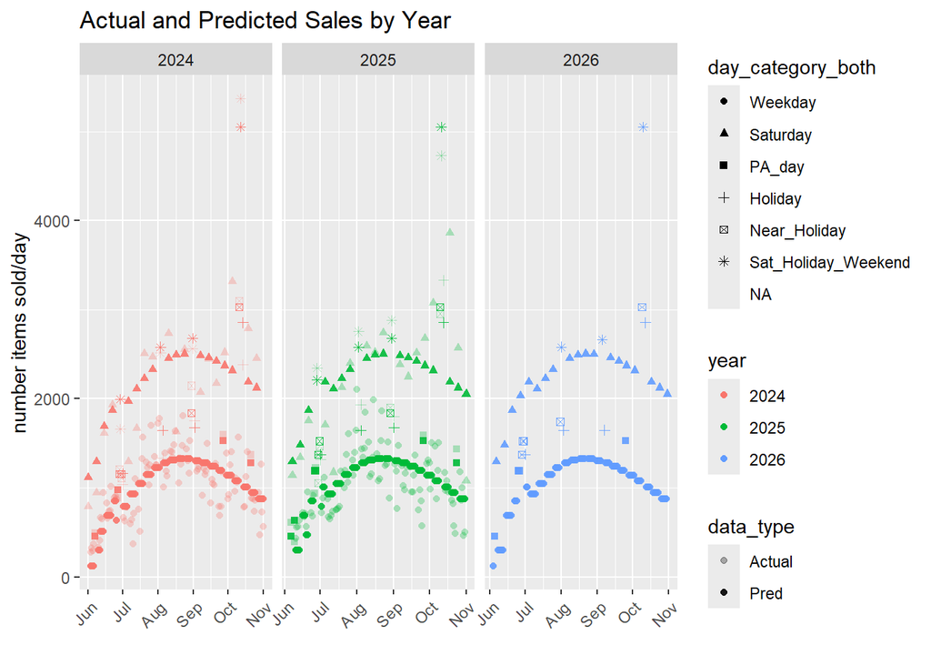

```r
data_comb %>% ggplot(aes(x = date,
                         y = num_items,
                         color = year,
                         shape = day_category_both,
                         alpha = data_type)) +
  geom_point() +
  scale_alpha_manual(values = c(Actual = 0.3, Pred = .9)) +
  theme(axis.text.x = element_text(angle = 45, hjust = 1)) +
  facet_wrap(~year, scales = "free_x") +
    labs(
    x = "",
    title = "Actual and Predicted Sales by Year",
    y = "number items sold/day"
  )
```

### 1.1.2 Relative to Median

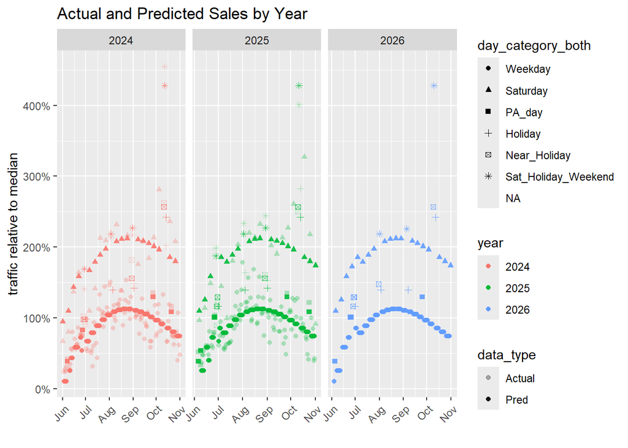

```r
data_comb %>% ggplot(aes(x = date,
                         y = items_rel_to_median,
                         color = year,
                         shape = day_category_both,
                         alpha = data_type)) +
  geom_point() +
  scale_alpha_manual(values = c(Actual = 0.3, Pred = .9)) +
  theme(axis.text.x = element_text(angle = 45, hjust = 1)) +
  facet_wrap(~year, scales = "free_x") +
  scale_y_continuous(labels = scales::percent_format()) +
  labs(
    x = "",
    title = "Actual and Predicted Sales by Year",
    y = "traffic relative to median"
  )
```

### 1.1.3 All together

Not as useful - too crazy

Shows shifting of dates back by one day each year

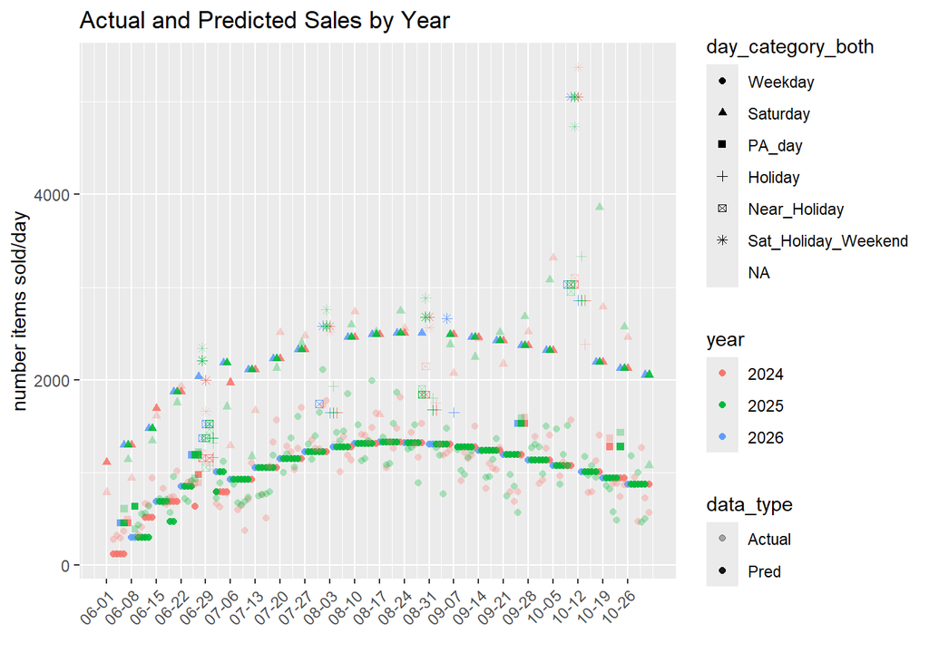

```r
data_comb %>% ggplot(aes(x = month_day,
                         y = num_items,
                         color = year,
                         shape = day_category_both,
                         alpha = data_type)) +
  geom_point() +
  scale_alpha_manual(values = c(Actual = 0.3, Pred = 0.9)) +
  scale_x_date(
    breaks = seq(as.Date("2000-06-01"), max(data_comb$month_day), by = "1 week"),
    date_labels = "%m-%d"
  ) +
  #geom_smooth(aes(group = 1),color = "grey", se = F) +
  theme(axis.text.x = element_text(angle = 45, hjust = 1)) +
  labs(
    x = "",
    title = "Actual and Predicted Sales by Year",
    y = "number items sold/day"
  )
```

## 1.2 Zoom in by week

```r
model_data$num_items %>% quantile()
```

```
##      0%     25%     50%     75%    100%
##  276.00  863.25 1180.00 1506.00 5372.00
```

```r
default_min = 1
default_max = 2
week_min = week_labels$season_week[default_min]
week_max = week_labels$season_week[default_max]

data_comb_filter <- data_comb %>% filter( season_week >= week_min &
                      season_week <= week_max )
```

### 1.2.1 Number of Items Sold

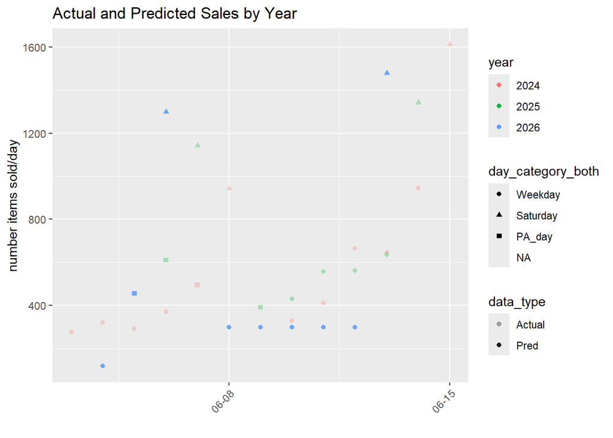

```r
data_comb_filter %>% filter(
  year == "2026" |
  (year != "2026" & data_type == "Actual")
) %>% ggplot(aes(x = month_day,
                         y = num_items,
                         color = year,
                         shape = day_category_both,
                         alpha = data_type)) +
  geom_point() +
  scale_alpha_manual(values = c(Actual = 0.3, Pred = 0.9)) +
  scale_x_date(
    breaks = seq(as.Date("2000-06-01"), max(data_comb$month_day), by = "1 week"),
    date_labels = "%m-%d"
  ) +
  #geom_smooth(aes(group = 1),color = "grey", se = F) +
  theme(axis.text.x = element_text(angle = 45, hjust = 1)) +
  labs(
    x = "",
    title = "Actual and Predicted Sales by Year",
    y = "number items sold/day"
  )
```

### 1.2.2 Relative to Median

This is one that seems most useful to me

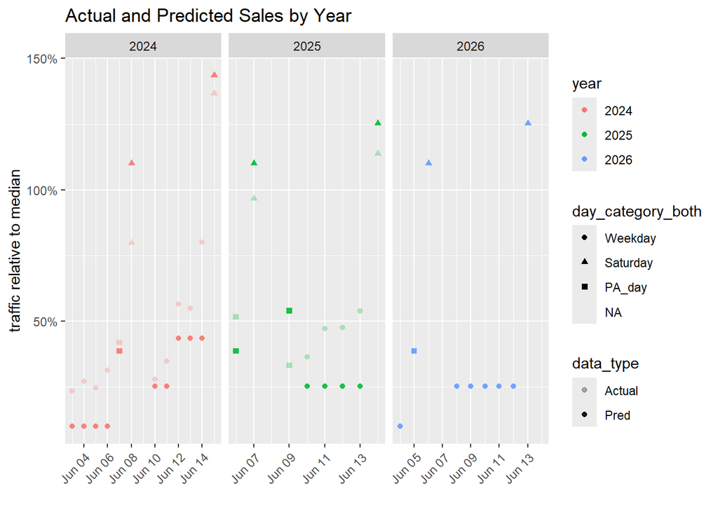

```r
data_comb_filter %>% ggplot(aes(x = date,
                         y = items_rel_to_median,
                         color = year,
                         shape = day_category_both,
                         alpha = data_type)) +
  geom_point() +
  scale_alpha_manual(values = c(Actual = 0.3, Pred = .9)) +
  theme(axis.text.x = element_text(angle = 45, hjust = 1)) +
  facet_wrap(~year, scales = "free_x") +
  scale_y_continuous(labels = scales::percent_format()) +
  labs(
    x = "",
    title = "Actual and Predicted Sales by Year",
    y = "traffic relative to median"
  )
```

## 1.3 Zoom in by week - Relative to median

```r
model_data$num_items %>% quantile()
```

```
##      0%     25%     50%     75%    100%
##  276.00  863.25 1180.00 1506.00 5372.00
```

```r
default_min = 1
default_max = 2
week_min = week_labels$season_week[default_min]
week_max = week_labels$season_week[default_max]

data_comb_filter <- data_comb %>% filter( season_week >= week_min &
                      season_week <= week_max )
```

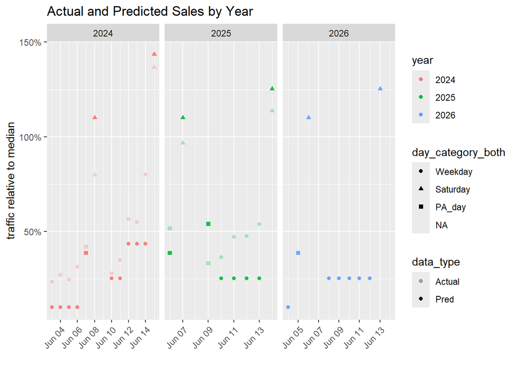

```r
data_comb_filter %>% ggplot(aes(x = date,
                         y = items_rel_to_median,
                         color = year,
                         shape = day_category_both,
                         alpha = data_type)) +
  geom_point() +
  scale_alpha_manual(values = c(Actual = 0.3, Pred = .9)) +
  theme(axis.text.x = element_text(angle = 45, hjust = 1)) +
  facet_wrap(~year, scales = "free_x") +
  scale_y_continuous(labels = scales::percent_format()) +
  labs(
    x = "",
    title = "Actual and Predicted Sales by Year",
    y = "traffic relative to median"
  )
```

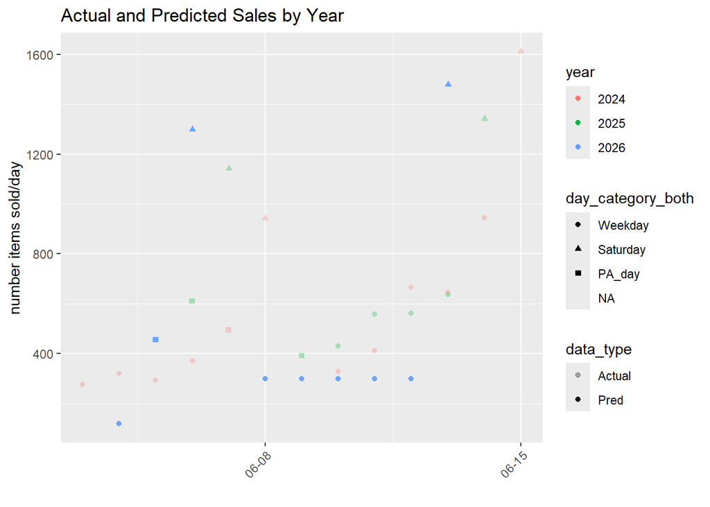

```r
data_comb_filter %>% filter(
  year == "2026" |
  (year != "2026" & data_type == "Actual")
) %>% ggplot(aes(x = month_day,
                         y = num_items,
                         color = year,
                         shape = day_category_both,
                         alpha = data_type)) +
  geom_point() +
  scale_alpha_manual(values = c(Actual = 0.3, Pred = 0.9)) +
  scale_x_date(
    breaks = seq(as.Date("2000-06-01"), max(data_comb$month_day), by = "1 week"),
    date_labels = "%m-%d"
  ) +
  #geom_smooth(aes(group = 1),color = "grey", se = F) +
  theme(axis.text.x = element_text(angle = 45, hjust = 1)) +
  labs(
    x = "",
    title = "Actual and Predicted Sales by Year",
    y = "number items sold/day"
  )
```

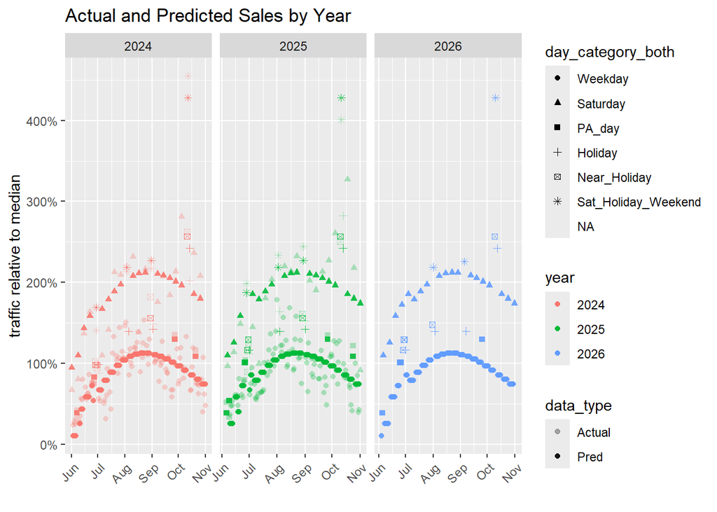

```r
data_comb %>% ggplot(aes(x = date,
                         y = items_rel_to_median,
                         color = year,
                         shape = day_category_both,
                         alpha = data_type)) +
  geom_point() +
  scale_alpha_manual(values = c(Actual = 0.3, Pred = .9)) +
  theme(axis.text.x = element_text(angle = 45, hjust = 1)) +
  facet_wrap(~year, scales = "free_x") +
  scale_y_continuous(labels = scales::percent_format()) +
  labs(
    x = "",
    title = "Actual and Predicted Sales by Year",
    y = "traffic relative to median"
  )
```

## 1.4 Weekly Metrics?

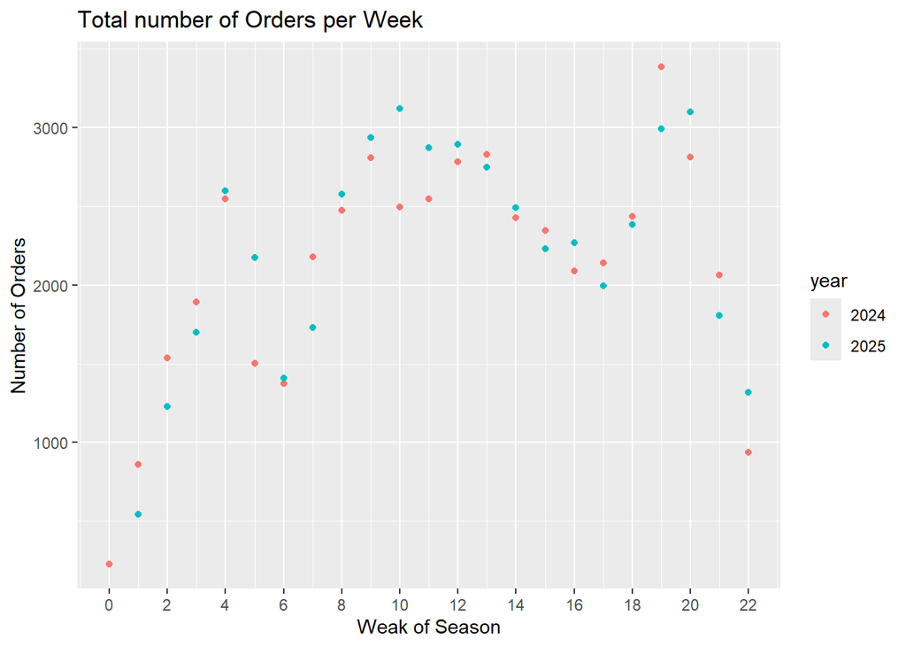

```r
week_metrics %>% ggplot(aes(season_week, num_orders, color = year)) +
  geom_point() +
  scale_x_continuous(breaks = seq(0, 22, by = 2)) +
  labs(
    title = "Total number of Orders per Week",
    y = "Number of Orders",
    x = "Weak of Season"
  )
```

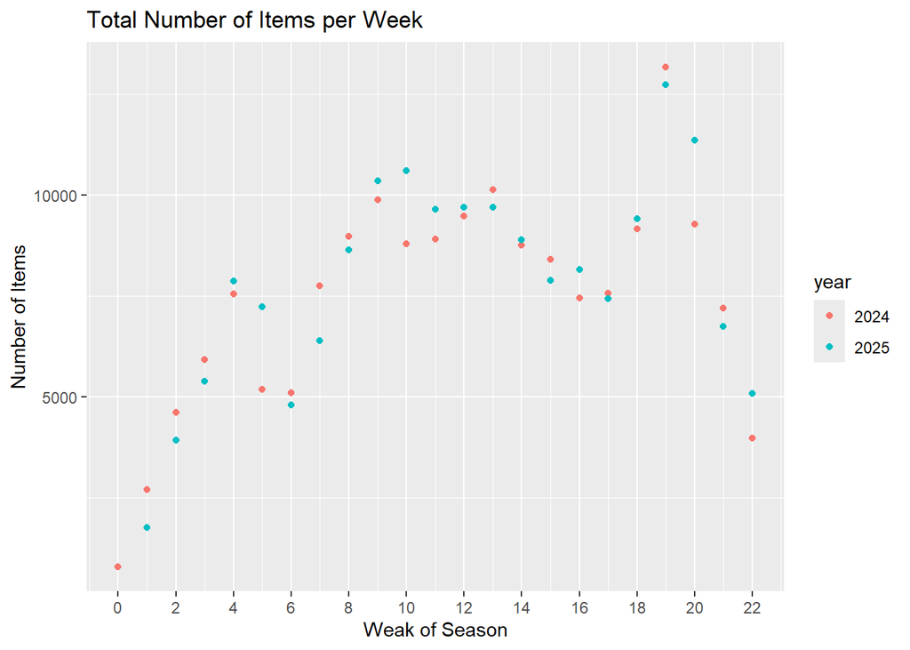

```r
week_metrics %>% ggplot(aes(season_week, num_items, color = year)) +
  geom_point() +
  scale_x_continuous(breaks = seq(0, 22, by = 2)) +
  labs(
    title = "Total Number of Items per Week",
    y = "Number of Items",
    x = "Weak of Season"
  )
```

### 1.4.3 Gross

[figure not shown]

```r
week_metrics %>% ggplot(aes(season_week, gross/1000, color = year)) +
  geom_point() +
  scale_x_continuous(breaks = seq(0, 22, by = 2)) +
  labs(
    title = "Total number of Orders per Week",
    y = "Gross (k$)",
    x = "Weak of Season"
  )
```

# 2 Bakery Orders

Predictions for a given day [day_selection] default June 4

I. Weather prediction summary:

- rainy = T/F
- extreme temp = T/F (outside 12-32 degrees C)
- high wind = T/F
- Category: good_weather, neutral_weather, or bad_weather
2. Order Summary:

(predicted baseline, predicted bad_day, predicted good_day, current overstock, recommended order) vs (type of bakery product)

3. Historical sales:

[week_selection] default to day_selection when day selection changes

Overview of historical sales surrounding that day (+1 week), with vertical line marking given day_selection.

# 3 Produce

Historical and predicted number of items sold per week by produce item by given range of weeks, given [week_selection_start] to [week_selection_end]

Items sold per week given range of weeks. Default: [week_selection = minimum] to [week_selection + 4]

produce